# Cleaning and Simulating Data

Kate Schertz

4/14/2020

```r
library(tidyverse)
theme_set(theme_minimal())
set.seed(42)
```

```r
dataset <- read_csv("topdownattention.csv")
```

```r
dataset$Image <- as.factor(dataset$Image)
dataset$MemLevel <- as.factor(dataset$MemLevel)
dataset$MemCue <- as.factor(dataset$MemCue)
dataset$Performance <- as.factor(dataset$Performance)
n <- length(unique(dataset$Subject))
```

## Cleaning Data

```r
bysubject <- dataset %>% group_by(Subject) %>% count(Performance)
head(bysubject)
```

```
## # A tibble: 6 x 3
## # Groups:   Subject [2]
##   Subject Performance     n
##     <dbl> <fct>       <int>
## 1       1 1              75
## 2       1 2              42
## 3       1 3               3
## 4       2 1              79
## 5       2 2              40
## 6       2 3               1
```

```r
#pivot_wider is going to take a name-value pair and spread it over multiple columns, and then we rename the columns so we don't have to remember the mapping
wide_bysubject <- bysubject %>%
  pivot_wider(names_from = Performance, values_from = n, values_fill = list(n = 0)) %>%
  rename(Correct=`1`, Incorrect=`2`, Timeout=`3`) %>%
  ungroup()
head(wide_bysubject)
```

```
## # A tibble: 6 x 4
##   Subject Correct Incorrect Timeout
##     <dbl>   <int>     <int>   <int>
## 1       1      75        42       3
## 2       2      79        40       1
## 3       3      93        25       2
## 4       4      82        37       1
## 5       5     100        20       0
## 6       6      97        23       0
```

```r
#Now we can calculate our hit rate (Correct/Correct + Incorrect). We will ignore Timeout.
wide_bysubject <- wide_bysubject %>% mutate(HitRate = Correct/(Correct + Incorrect))
head(wide_bysubject)
```

```
## # A tibble: 6 x 5
##   Subject Correct Incorrect Timeout HitRate
##     <dbl>   <int>     <int>   <int>   <dbl>
## 1       1      75        42       3   0.641
## 2       2      79        40       1   0.664
## 3       3      93        25       2   0.788
## 4       4      82        37       1   0.689
## 5       5     100        20       0   0.833
## 6       6      97        23       0   0.808
```

Let’s look at overall performance using a boxplot to see if there are any outliers

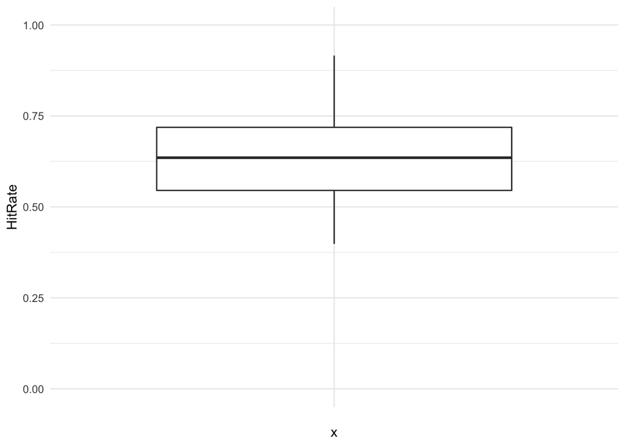

```r
ggplot(data=wide_bysubject) +
  aes(x="",y=HitRate) +
  geom_boxplot() +
  ylim(0,1)
```

What about identifying participants who “timed out” too much? This could indicate they are not being active participants.

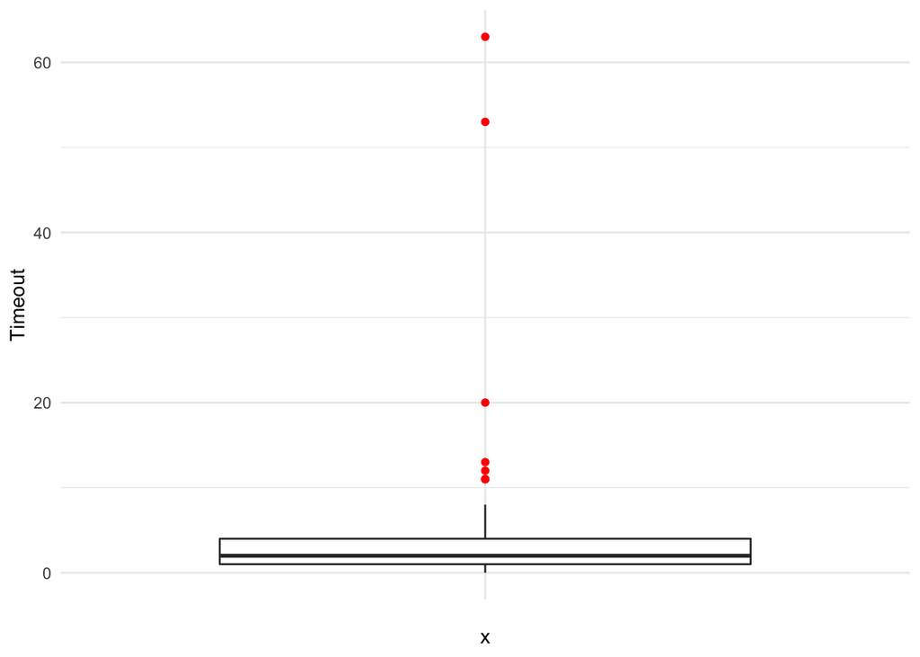

```r
ggplot(data=wide_bysubject) +
  aes(x="",y=Timeout) +
  geom_boxplot(outlier.colour = "red")
```

Looks like we have a few people that were not responding properly. Let’s identify and remove those subjects.

```r
summary(wide_bysubject$Timeout)
```

```
##    Min. 1st Qu.  Median    Mean 3rd Qu.    Max.
##   0.000   1.000   2.000   4.431   4.000  63.000
```

```r
#THIS SECTION WAS CHANGED FROM VERSION 1 THAT WAS POSTED.
#IQR is a function in dplyr which returns the Inter-quartile range. quantile returns the quantiles of the data (We need the 4th item from the list that quantiles outputs because that's the 3rd Quantile)
wide_bysubject <- wide_bysubject %>% mutate(outlier = Timeout > quantile(wide_bysubject$Timeout)[4] + IQR(Timeout)*1.5)
head(wide_bysubject)
```

```
## # A tibble: 6 x 6
##   Subject Correct Incorrect Timeout HitRate outlier
##     <dbl>   <int>     <int>   <int>   <dbl> <lgl>
## 1       1      75        42       3   0.641 FALSE
## 2       2      79        40       1   0.664 FALSE
## 3       3      93        25       2   0.788 FALSE
## 4       4      82        37       1   0.689 FALSE
## 5       5     100        20       0   0.833 FALSE
## 6       6      97        23       0   0.808 FALSE
```

```r
#You can check this manually.
quantile(wide_bysubject$Timeout) #Gives 5 values (0/25/50/75/100 percentiles)
```

```
##   0%  25%  50%  75% 100%
##    0    1    2    4   63
```

```r
quantile(wide_bysubject$Timeout)[2]
```

```
## 25%
##   1
```

```r
quantile(wide_bysubject$Timeout)[4]
```

```
## 75%
##   4
```

```r
iqr <- 4-1
4 + 1.5*3
```

```
## [1] 8.5
```

```r
wide_bysubject <- wide_bysubject %>% mutate(outlierTestManual = Timeout > 8.5)

wide_bysubject %>% filter(outlier == TRUE)
```

```
## # A tibble: 8 x 7
##   Subject Correct Incorrect Timeout HitRate outlier outlierTestManual
##     <dbl>   <int>     <int>   <int>   <dbl> <lgl>   <lgl>
## 1       8      58        49      13   0.542 TRUE    TRUE
## 2      11      59        49      12   0.546 TRUE    TRUE
## 3      16      33        24      63   0.579 TRUE    TRUE
## 4      18      53        47      20   0.53  TRUE    TRUE
## 5      20      31        36      53   0.463 TRUE    TRUE
## 6      21      56        53      11   0.514 TRUE    TRUE
## 7      23      65        44      11   0.596 TRUE    TRUE
## 8      66      59        50      11   0.541 TRUE    TRUE
```

That last command only kept the outliers. We need to filter them out instead.

```r
wide_bysubject_nooutliers <- wide_bysubject %>% filter(outlier != TRUE)
```

## Data Simulation

Let’s create toy data that is the same size as this data to make visualizations of expected results under different conditions. We had 72 participants who saw 120 images each. One way to set it up is to use our old dataframe and assign new values for Performance.

First let’s use fully coded data to show maximum differences between MemLevels.

```r
dataset_codedtoy <- dataset %>% select(-Performance) %>% mutate(Performance = NA)

#This is conditionally setting Performance based on the Memorability Levels
dataset_codedtoy <- dataset_codedtoy %>%
  mutate(Performance = case_when(
    MemLevel == "1" ~ 2, # Low Memorability, All incorrect
    MemLevel == "2" ~ 2, # Medium Memorability, All incorrect
    MemLevel == "3" ~ 1, # High Memorability, All correct
    MemLevel == "4" ~ 1  # Foils, All correct
  ))
```

Now we need to repeat the steps we took last time to calculate hit rate for the groups, this time without creating an intermediate dataframe.

```r
wide_toycoded <- dataset_codedtoy %>%
  group_by(Subject, MemLevel, MemCue) %>%
  count(Performance) %>%
  pivot_wider(names_from = Performance, values_from = n, values_fill = list(n = 0)) %>%
  rename(Correct=`1`, Incorrect=`2`) %>%
  ungroup() %>%
  filter(MemLevel != "4") %>%
  mutate(HitRate = Correct/(Correct + Incorrect))
head(wide_toycoded)
```

```
## # A tibble: 6 x 6
##   Subject MemLevel MemCue Incorrect Correct HitRate
##     <dbl> <fct>    <fct>      <int>   <int>   <dbl>
## 1       1 1        1             10       0       0
## 2       1 1        2             10       0       0
## 3       1 2        1             10       0       0
## 4       1 2        2             10       0       0
## 5       1 3        1              0      10       1
## 6       1 3        2              0      10       1
```

Let’s visualize this dataset to make sure it matches what we expect.

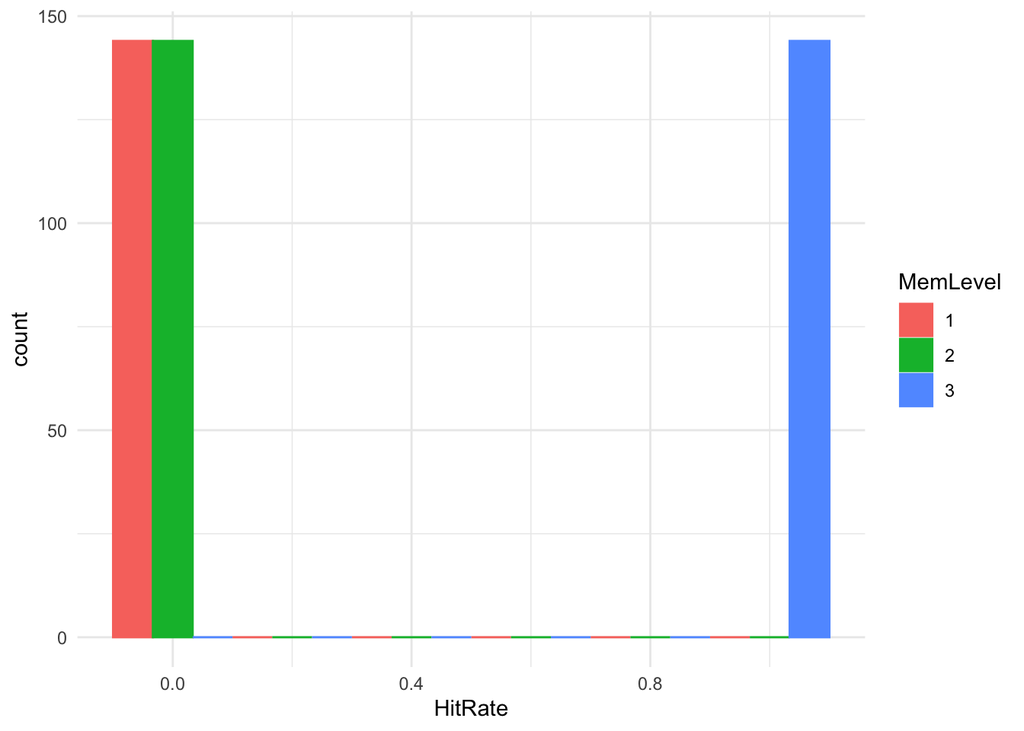

```r
ggplot(data=wide_toycoded) +
  aes(x = HitRate, fill=MemLevel, color=MemLevel) +
  geom_histogram(binwidth = .2, position = "dodge")
```

We can also summarize the dataframe to make a barplot

```r
HRbyCond <- wide_toycoded %>% group_by(MemLevel) %>% summarise(meanHR = mean(HitRate), sdHR = sd(HitRate))
HRbyCond
```

```
## # A tibble: 3 x 3
##   MemLevel meanHR  sdHR
##   <fct>     <dbl> <dbl>
## 1 1             0     0
## 2 2             0     0
## 3 3             1     0
```

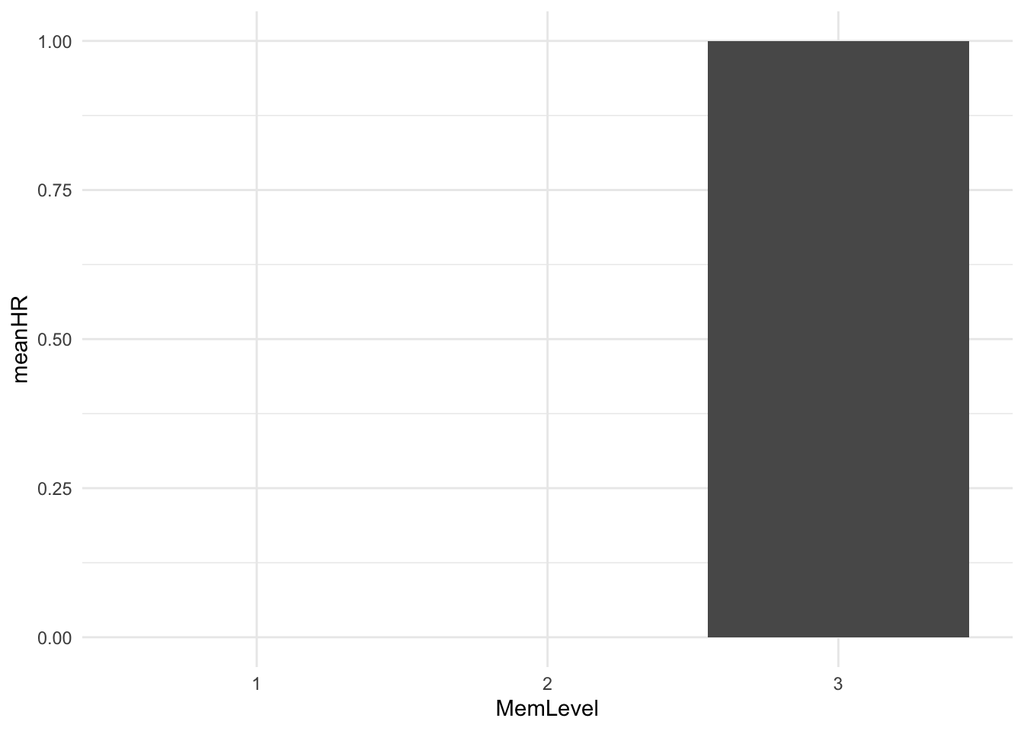

```r
ggplot(data=HRbyCond) + aes(x = MemLevel, y=meanHR) + geom_bar(stat = "identity")
```

Now let’s make random data.

```r
dataset_randomtoy <- dataset %>% select(-Performance) %>% mutate(Performance = NA)

#Creating a vector of random Correct/Incorrect
randperf <- sample(c(1,2), size=nrow(dataset_randomtoy), replace = TRUE)

#Assigning Performance to equal that vector
dataset_randomtoy$Performance <- randperf

wide_randomtoy <- dataset_randomtoy %>%
  group_by(Subject, MemLevel, MemCue) %>%
  count(Performance) %>%
  pivot_wider(names_from = Performance, values_from = n, values_fill = list(n = 0)) %>%
  rename(Correct=`1`, Incorrect=`2`) %>%
  ungroup() %>%
  filter(MemLevel != "4") %>%
  mutate(HitRate = Correct/(Correct + Incorrect))
head(wide_randomtoy)
```

```
## # A tibble: 6 x 6
##   Subject MemLevel MemCue Correct Incorrect HitRate
##     <dbl> <fct>    <fct>    <int>     <int>   <dbl>
## 1       1 1        1            4         6     0.4
## 2       1 1        2            5         5     0.5
## 3       1 2        1            5         5     0.5
## 4       1 2        2            2         8     0.2
## 5       1 3        1            4         6     0.4
## 6       1 3        2            4         6     0.4
```

Now what does our histogram look like if we use this data?

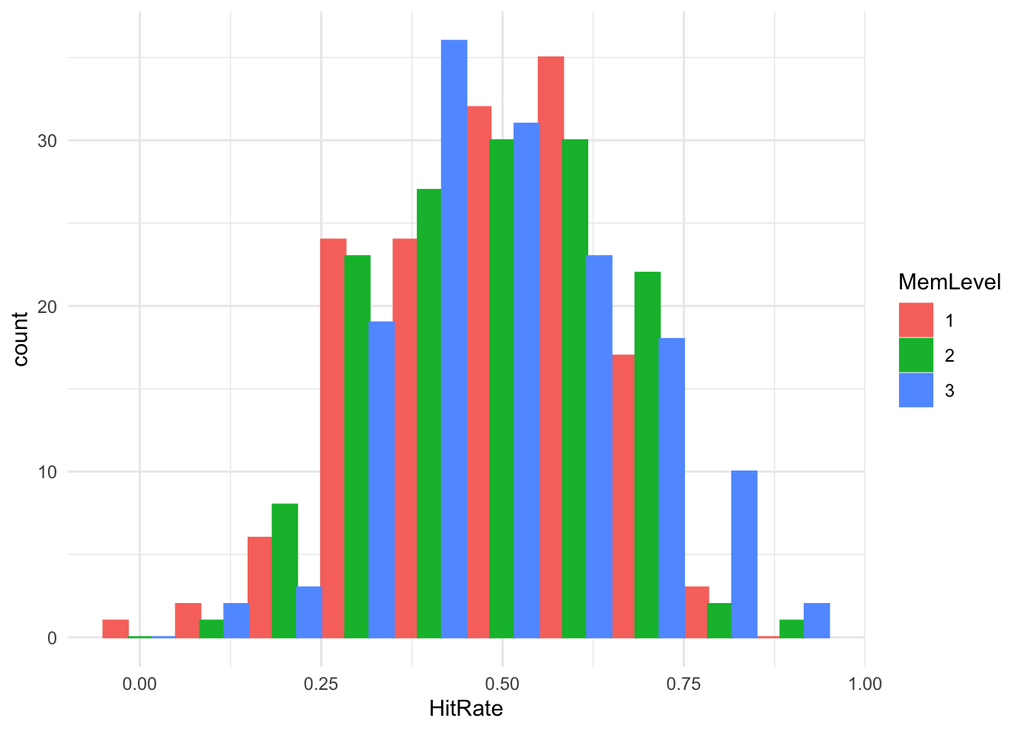

```r
ggplot(data=wide_randomtoy) +
  aes(x = HitRate, fill=MemLevel, color=MemLevel) +
  geom_histogram(binwidth = .1, position = "dodge")
```

And looking at the barplot

```r
HRbyCond_random <- wide_randomtoy %>% group_by(MemLevel) %>% summarise(meanHR = mean(HitRate), sdHR = sd(HitRate))
HRbyCond_random
```

```
## # A tibble: 3 x 3
##   MemLevel meanHR  sdHR
##   <fct>     <dbl> <dbl>
## 1 1         0.483 0.158
## 2 2         0.488 0.158
## 3 3         0.504 0.165
```

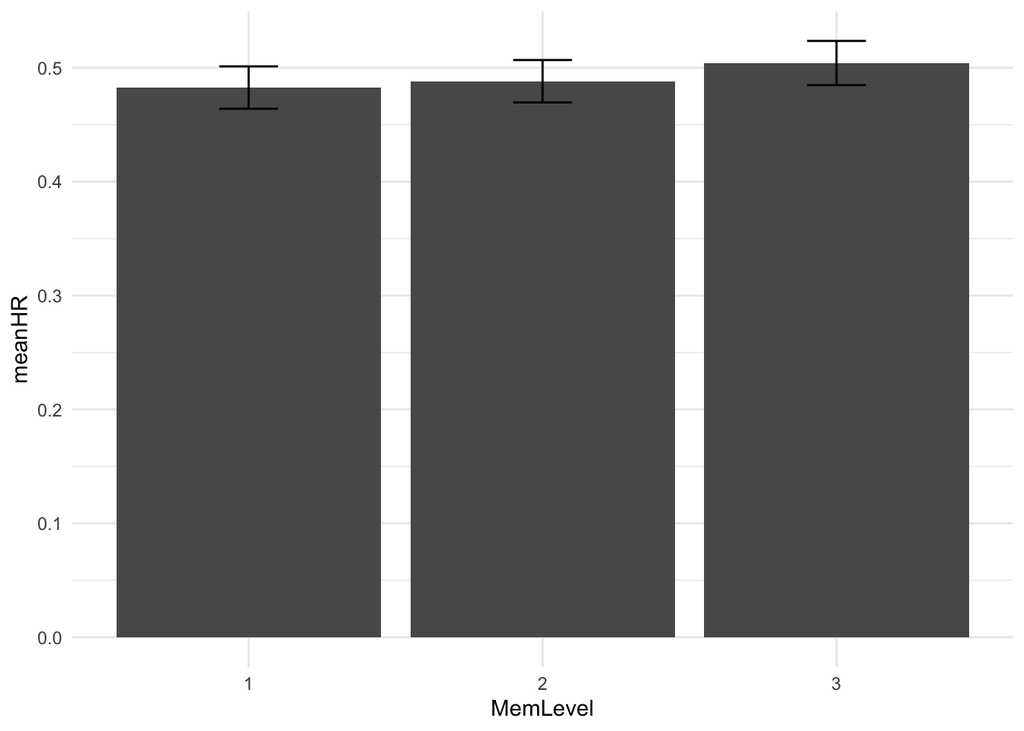

```r
ggplot(data=HRbyCond_random) +
  aes(x = MemLevel, y=meanHR) + geom_bar(stat = "identity") +
  geom_errorbar(aes(ymin=meanHR-(sdHR/sqrt(n)), ymax=meanHR+(sdHR/sqrt(n))), width=.2)
```

Other ways to make random data:

```r
#Here we are randomizing the performance data that is already present, so it's not ~50-50 correct/incorrect. The overall mean performance here should be equal to the mean performance of the actual data
dataset_shuffledperf <- as_tibble(transform(dataset, Performance = sample(Performance)))
# You can see that only the Performance column has changed. We could then repeat the steps above to visualize.
head(dataset)
```

```
## # A tibble: 6 x 6
##   Image MemLevel MemCue    RT Performance Subject
##   <fct> <fct>    <fct>  <dbl> <fct>         <dbl>
## 1 117   4        3        939 2                 1
## 2 88    4        3        704 1                 1
## 3 99    4        3        710 1                 1
## 4 13    1        2        709 2                 1
## 5 70    4        3        862 2                 1
## 6 30    2        2        735 1                 1
```

```r
head(dataset_shuffledperf)
```

```
## # A tibble: 6 x 6
##   Image MemLevel MemCue    RT Performance Subject
##   <fct> <fct>    <fct>  <dbl> <fct>         <dbl>
## 1 117   4        3        939 1                 1
## 2 88    4        3        704 1                 1
## 3 99    4        3        710 1                 1
## 4 13    1        2        709 1                 1
## 5 70    4        3        862 1                 1
## 6 30    2        2        735 2                 1
```

We can also sample hit rates from different distributions to create hit rates that are different for the Memorability levels but still have variance (unlike our fully coded data). Let’s make this dataset from scratch instead of editing our original data frame.

We create a vector for each of our six conditions and then bind them together into a data frame/tibble.

```r
subjects <- as.factor(c(1:72))
LowForget <- rnorm(n=72, mean=.4, sd=.05)
LowRemember <- rnorm(n=72, mean=.4, sd=.05)
MedForget <- rnorm(n=72, mean=.5, sd=.05)
MedRemember <- rnorm(n=72, mean=.5, sd=.05)
HighForget <- rnorm(n=72, mean=.7, sd=.05)
HighRemember <- rnorm(n=72, mean=.7, sd=.05)

toyranddist <- tibble(subjects, LowForget, LowRemember, MedForget, MedRemember, HighForget, HighRemember)
head(toyranddist)
```

```
## # A tibble: 6 x 7
##   subjects LowForget LowRemember MedForget MedRemember HighForget HighRemember
##   <fct>        <dbl>       <dbl>     <dbl>       <dbl>      <dbl>        <dbl>
## 1 1            0.399       0.416     0.425       0.516      0.668        0.736
## 2 2            0.451       0.363     0.411       0.492      0.676        0.692
## 3 3            0.345       0.385     0.442       0.503      0.635        0.641
## 4 4            0.299       0.434     0.440       0.598      0.690        0.658
## 5 5            0.443       0.448     0.494       0.468      0.644        0.712
## 6 6            0.328       0.424     0.425       0.449      0.713        0.720
```

```r
#pivot_longer is the inverse transformation of pivot_wider. Every column except subjects is being placed into two new columns. The column names will be in the "condition" column, while their values will be in the "HitRate" column. Subjects will be repeated to fill the dataframe.
long_toyranddist <- pivot_longer(data=toyranddist,cols = -subjects ,names_to = "condition", values_to = "HitRate")
summary(long_toyranddist)
```

```
##     subjects    condition            HitRate
##  1      :  6   Length:432         Min.   :0.2384
##  2      :  6   Class :character   1st Qu.:0.4173
##  3      :  6   Mode  :character   Median :0.4878
##  4      :  6                      Mean   :0.5292
##  5      :  6                      3rd Qu.:0.6685
##  6      :  6                      Max.   :0.8409
##  (Other):396
```

Let’s see what it looks like to plot these distributions.

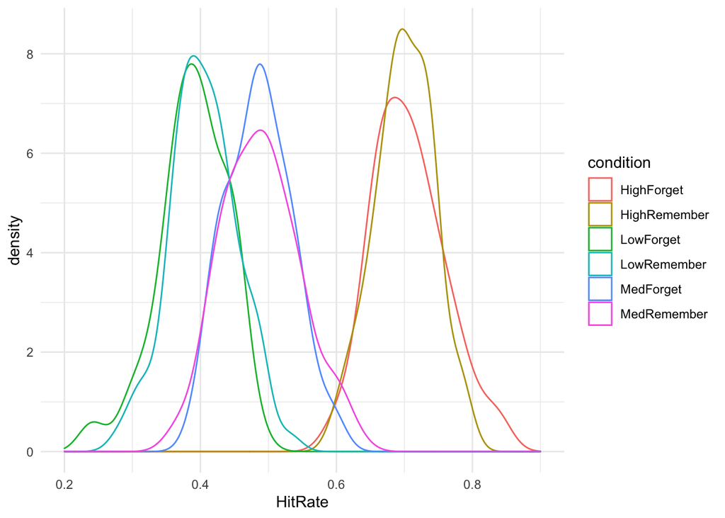

```r
ggplot(data=long_toyranddist) +
  aes(x = HitRate, color=condition) +
  geom_density(position = "identity") +
  xlim(.2,.9)
```